# R beyond Data Analysis

Charlotte Haussmann

Uni.lu

2024-06-18

Abstract

Here we learn how to write a *plotting function*.

### How to write a plotting function

First we read load the packages *haven* and *ggplot2*.

```r
library(haven)
library(ggplot2)
```

The next step is to load the data from Stanciu et al. (2017).

```r
df <- read_sav("data/sample.sav")
```

After that we are creating a function for plotting.

##### Let’s look at it, step by step.

We create a new object **func_plot**. This function accesses a **data set** and the **variables** contained in it

```r
func_plot <- function(data, variable){

}
```

First we want to check if the called variable is inside the data set. If not, there will be a warning message displayed: *“Variable not found in data frame”*.

```r
func_plot <- function(data, variable){

  if (!(variable %in% names(data))) {
    stop("Variable not found in data frame")
  }}
```

After that we check if the variable is or is not numeric. If the variable is **not** numeric, the warning message *“Variable is not numeric”* will be displayed.

```r
func_plot <- function(data, variable){

  if (!(variable %in% names(data))) {
    stop("Variable not found in data frame")
  }

  if(!is.numeric(data[[variable]])) {
    stop("Variable is not numeric")
  }}
```

The last step is to great a plot with the package *ggplot2*. We are creating a histogram with *geom_bar* and customized colours and title.

```r
func_plot <- function(data, variable){

  if (!(variable %in% names(data))) {
    stop("Variable not found in data frame")
  }

  if(!is.numeric(data[[variable]])) {
    stop("Variable is not numeric")
  }

  ggplot(data, aes_string(x = variable)) +
    geom_bar(fill = "skyblue", color = "black") +
    labs(title = paste("Histogram of", variable),
         x = variable,
         y = "Frequency") +
    theme_minimal()

}
```

Now we will use this new function with the variable **gen** which stands for gender, with ($1=female;2=male$).

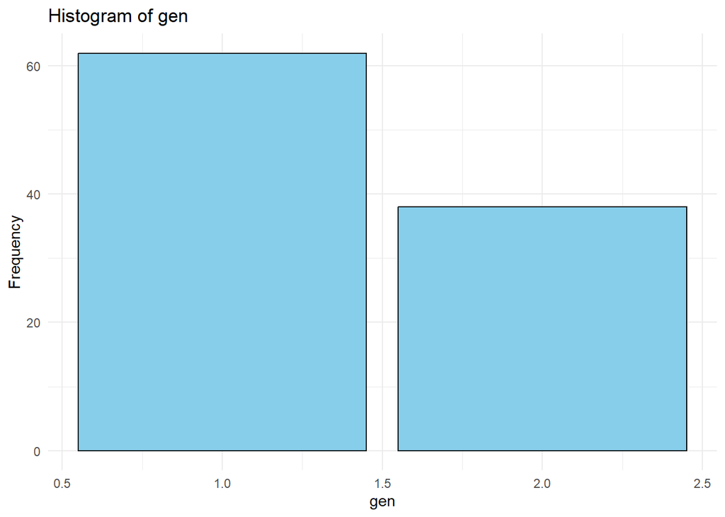

```r
func_plot(df, "gen")
```

And once again, with the variable **age**.

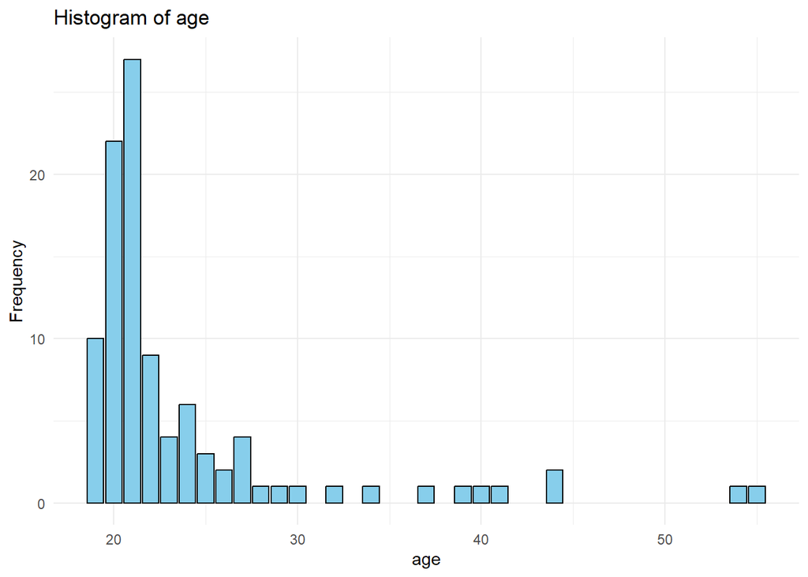

```r
func_plot(df, "age")
```

And a last time with **men_warm**.

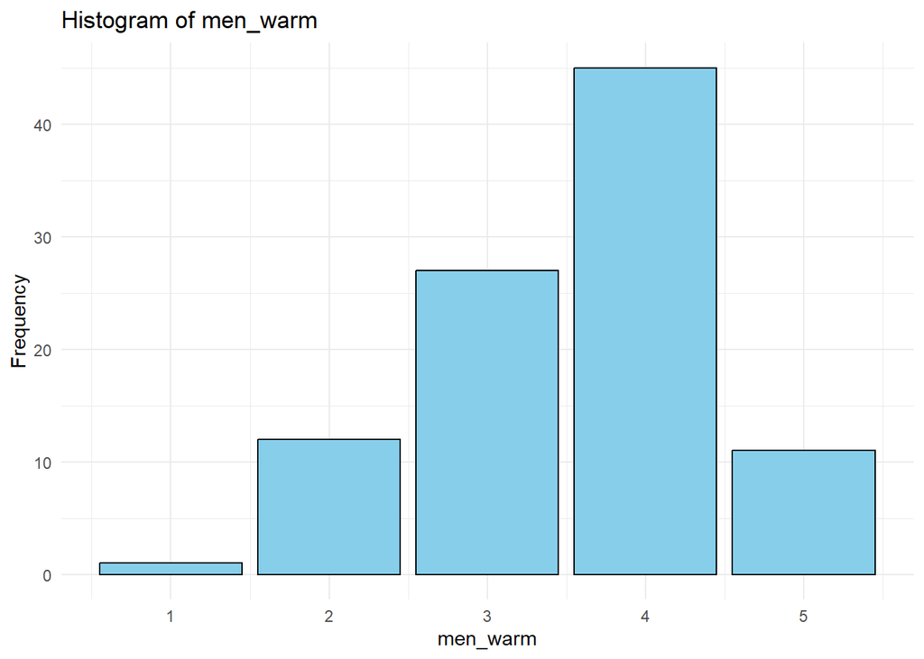

```r
func_plot(df, "men_warm")
```

## Plain vs. live text

```r
pacman::p_load(tidyverse, readxl, haven, sjlabelled, BiocManager, kableExtra)
# create an object dataframe example `dfex` and assign to it the .sav file `sample.sav` that was introduced previously
dfex<-haven::read_sav("data/sample.sav")

# create an object movies metadata `dfmv` and assign to it the .xlsx file `movies.xlsx`
# note the different paths to these files
# note that we specify which sheet to read too; here only sheet 1 is imported
dfmv<-readxl::read_excel("data/movies.xlsx",1)

# next, we check if the source material was imported successfully by observing the first lines in the tables
head(dfex)
```

```
## # A tibble: 6 × 9
##     ppn gen          age res       res_other men_warm men_comp wom_warm wom_comp
##   <dbl> <dbl+lbl>  <dbl> <dbl+lbl> <chr>     <dbl+lb> <dbl+lb> <dbl+lb> <dbl+lb>
## 1   459 1 [Female]    24  5 [Iasi] -99        3 [Und…  4 [Agr… 3 [Unde… 4 [Agre…
## 2   592 2 [Male]      21  5 [Iasi] -99        3 [Und…  4 [Agr… 3 [Unde… 3 [Unde…
## 3   634 2 [Male]      21 NA        petrosani  4 [Agr…  5 [Str… 4 [Agre… 4 [Agre…
## 4   369 1 [Female]    30  8 [Gala… -99       NA       NA       4 [Agre… 4 [Agre…
## 5   121 1 [Female]    21  4 [Timi… -99        4 [Agr…  3 [Und… 3 [Unde… 4 [Agre…
## 6   127 1 [Female]    20  4 [Timi… -99        4 [Agr…  4 [Agr… 4 [Agre… 2 [Disa…
```

```r
head(dfmv)
```

```
## # A tibble: 6 × 6
##   Movie                       Actor                 Like  Why     Grade Wikilink
##   <chr>                       <chr>                 <chr> <chr>   <dbl> <chr>
## 1 John Wick                   Keanu Reeves          Yes   Fight …    10 https:/…
## 2 Call me by your name        Timothee Chalamet     Yes   Beauti…    10 https:/…
## 3 Terminator                  Arnold Schwarzenegger Yes   Arnold      9 https:/…
## 4 4 months 3 weeks and 2 days <NA>                  Yes   Portra…     8 https:/…
## 5 Bones and All               Timothee Chalamet     No    Long s…     5 https:/…
## 6 The Hunt for Red October    Alec Baldwin          No    Fav Mo…     1 https:/…
```

This is an example of how automatization can be implemented in the work flow. My list of movies include 6 entries. The title of those movies are John Wick, Call me by your name, Terminator, 4 months 3 weeks and 2 days, Bones and All, The Hunt for Red October . Is there a movie that I actually don’t like on that list, well, the answer is that I dislike exactly 2 movies on that list.  
On average I liked all movies on a grade of 7.1666667 with the lowest rating of 1 to the max rating of 10.

The regression shows that age have an effect of -0.0059283 with a p-value of 0.6578563. The estimator is not significant. Gender has an effect of 0.083075 with a p-value of 0.6654052. The estimator is not significant.

## New Movie Tabels and Plots

```r
dfmv %>% knitr::kable(caption="Simple table using knitr::kable()",format = "pipe")
```

Simple table using knitr::kable()

| Movie | Actor | Like | Why | Grade | Wikilink |
| --- | --- | --- | --- | --- | --- |
| John Wick | Keanu Reeves | Yes | Fight scenes | 10 | https://en.wikipedia.org/wiki/John_Wick_(film) |
| Call me by your name | Timothee Chalamet | Yes | Beautiful love story | 10 | https://en.wikipedia.org/wiki/Call_Me_by_Your_Name_(film) |
| Terminator | Arnold Schwarzenegger | Yes | Arnold | 9 | https://en.wikipedia.org/wiki/The_Terminator |
| 4 months 3 weeks and 2 days | NA | Yes | Portrayal of life in communist Romania | 8 | https://en.wikipedia.org/wiki/4_Months%2C_3_Weeks_and_2_Days |
| Bones and All | Timothee Chalamet | No | Long storytelling | 5 | https://en.wikipedia.org/wiki/Bones_and_All |
| The Hunt for Red October | Alec Baldwin | No | Fav Movie of my Ex | 1 | https://en.wikipedia.org/wiki/The_Hunt_for_Red_October_(film) |

```r
# does some data manipulation to retrieve the required information
tmptbl<-dfmv %>%
  filter(Actor %in% c("Keanu Reeves", "Alec Baldwin"))

# creates an empty table holder that is our summary table that we'd
# want to include in the final output document
extbl<-tibble(

  like=tmptbl[ tmptbl$Grade >= 8 |tmptbl$Grade <= 5 & tmptbl$Like %in% c("Yes","No"), ]$Like,
  name=tmptbl[ tmptbl$Grade >= 8 |tmptbl$Grade <= 5 & tmptbl$Like %in% c("Yes","No"), ]$Actor,
  movie=tmptbl[ tmptbl$Grade >= 8 |tmptbl$Grade <= 5 & tmptbl$Like %in% c("Yes","No"), ]$Movie,
  wiki=tmptbl[ tmptbl$Grade >= 8 |tmptbl$Grade <= 5 & tmptbl$Like %in% c("Yes","No"), ]$Wikilink
  )
```

```r
extbl %>% knitr::kable(caption="Movies graded 8 or more from liked and least like actors with Keanu Reeves and Alec Baldwin", format="pipe")
```

| like | name | movie | wiki |
| --- | --- | --- | --- |
| Yes | Keanu Reeves | John Wick | https://en.wikipedia.org/wiki/John_Wick_(film) |
| No | Alec Baldwin | The Hunt for Red October | https://en.wikipedia.org/wiki/The_Hunt_for_Red_October_(film) |

```r
# we remove all the labels using the package sjlabelled and mutate
# as factors columns gen and res
# this step makes it easier later on to work with plots
# note that it is not a necessary step in general but only for the sake of
# simplicity here
dfex<-dfex %>% sjlabelled::remove_all_labels() %>%
  mutate(gen=factor(gen),
         res=factor(res))

# subsamples 15 study participants at random
tmpdf1<-sample_n(dfex,15)
# subsample 60 study participants at random
tmpdf2<-sample_n(dfex,60)
```

```r
haven::write_sav(tmpdf1,"data/tmpdf1.sav")
haven::write_sav(tmpdf2,"data/tmpdf2.sav")
```

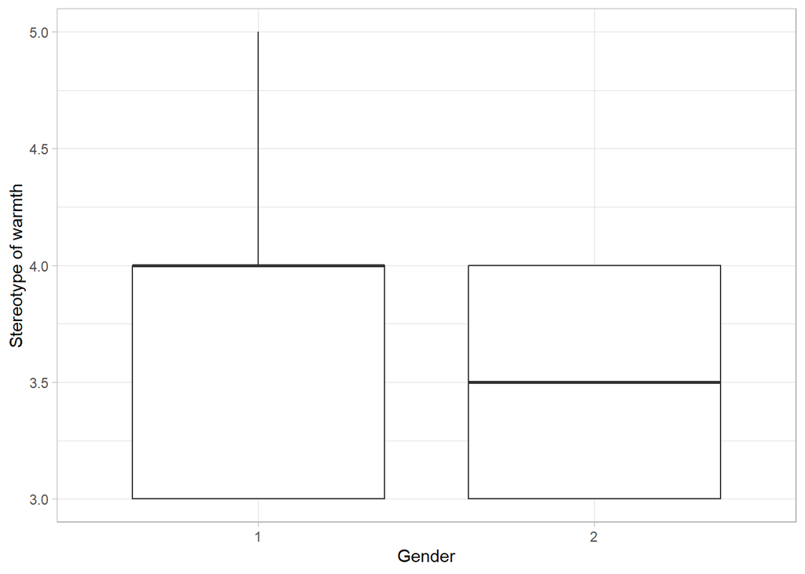

```r
# import dataset into one object and then subject this object to the ggplot code

# 1 - imports dataset into object tempdf
tempdf<-haven::read_sav("data/tmpdf1.sav") %>% sjlabelled::remove_all_labels() %>%
  mutate(gen=factor(gen),
         res=factor(res))

# 2 - applies the ggplot to the dataset
ggplot(tempdf, aes(x=gen, y=wom_warm)) +
  labs(x="Gender",
       y="Stereotype of warmth") +
  geom_boxplot() +
  theme_light()
```

```r
# 3 - for illustration purposes, repeat step 1 with each
# of the three datasets (tmpdf1,tmpdf2 and dfex)
# making sure they are assigned into the same object tempdf.
# As long as the ggplot code is applied to a dataset with the same structure
# and variable labels the output will be updated automatically.
```

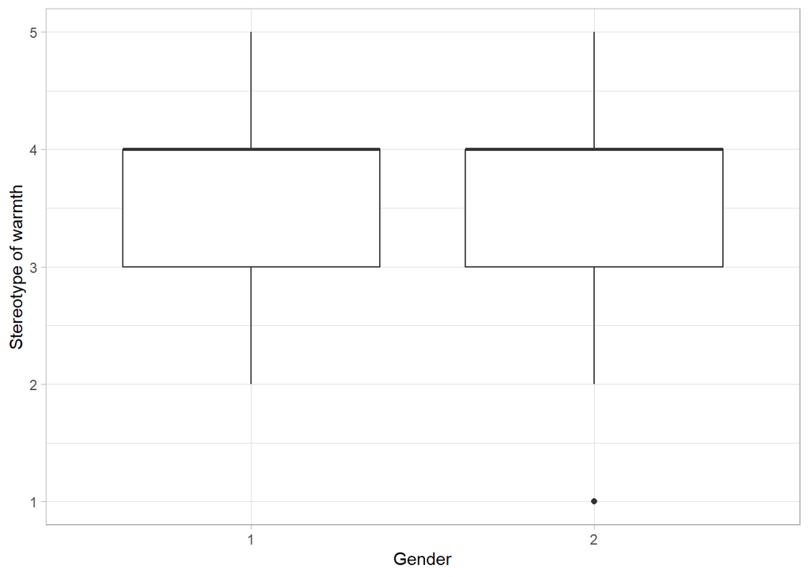

```r
# import dataset into one object and then subject this object to the ggplot code

# 1 - imports dataset into object tempdf
tempdf<-haven::read_sav("data/tmpdf2.sav") %>% sjlabelled::remove_all_labels() %>%
  mutate(gen=factor(gen),
         res=factor(res))

# 2 - applies the ggplot to the dataset
ggplot(tempdf, aes(x=gen, y=wom_warm)) +
  labs(x="Gender",
       y="Stereotype of warmth") +
  geom_boxplot() +
  theme_light()
```

```r
# 3 - for illustration purposes, repeat step 1 with each
# of the three datasets (tmpdf1,tmpdf2 and dfex)
# making sure they are assigned into the same object tempdf.
# As long as the ggplot code is applied to a dataset with the same structure
# and variable labels the output will be updated automatically.
```

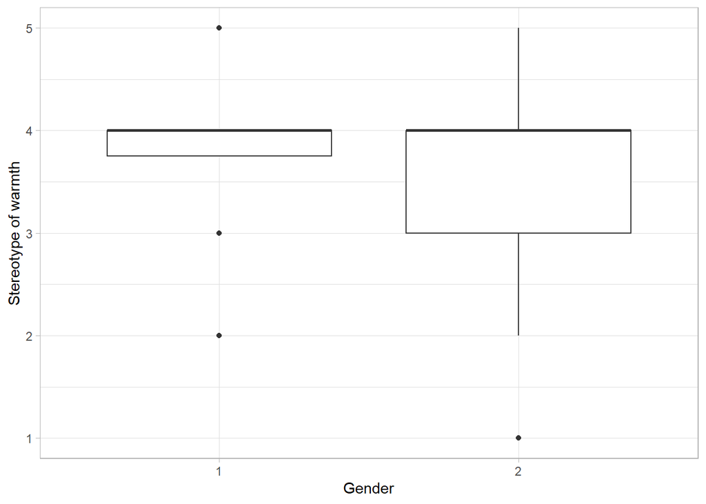

```r
# import dataset into one object and then subject this object to the ggplot code

# 1 - imports dataset into object tempdf
tempdf<-haven::read_sav("data/sample.sav") %>% sjlabelled::remove_all_labels() %>%
  mutate(gen=factor(gen),
         res=factor(res))

# 2 - applies the ggplot to the dataset
ggplot(tempdf, aes(x=gen, y=wom_warm)) +
  labs(x="Gender",
       y="Stereotype of warmth") +
  geom_boxplot() +
  theme_light()
```

```r
# 3 - for illustration purposes, repeat step 1 with each
# of the three datasets (tmpdf1,tmpdf2 and dfex)
# making sure they are assigned into the same object tempdf.
# As long as the ggplot code is applied to a dataset with the same structure
# and variable labels the output will be updated automatically.
```